# Practice 7.4

# Visualization

## Load required libraries

```r
library(xUCINET)
library(statnet)
```

## Using shape, color, size on Krackhardt’s friendship network

- How to use shape, color and size of points to represent attributes for the friendship network among Krackhardt’s high-tech managers (Figures 7.13 and 7.14)

First, we need to recreate the minimized Friendship network from Practice 7.1

```r
Krackhardt_HighTech$Friendship_SymMin <- xSymmetrize(Krackhardt_HighTech$Friendship, Type="Min")
```

We will define the node size based on the Tenure attribute of the nodes

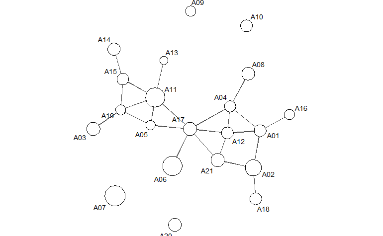

```r
par(mar=c(0,0,0,0))
gplot(Krackhardt_HighTech$Friendship_SymMin,
      gmode="graph",
      edge.col="grey30",
      edge.lwd=.4,
      vertex.cex=Krackhardt_HighTech$Attributes$Tenure/20+1,
      vertex.col="white",
      displaylabels=TRUE,
      label.cex=.8)
```

Now we draw the network, where symbol size again represents tenure and node color and shape representing level of formal seniority.

To define the shapes we rely on the argument **vertex.sides**, which creates a shape with a certain number of vertices, meaning that we get a triangle when a value 3 is used, a diamond for a value 4 and a circle when a value 50 is used.

We also rely on the fact that the color scheme used here means that color=1 is black, color=0 is white and color=2 is red.

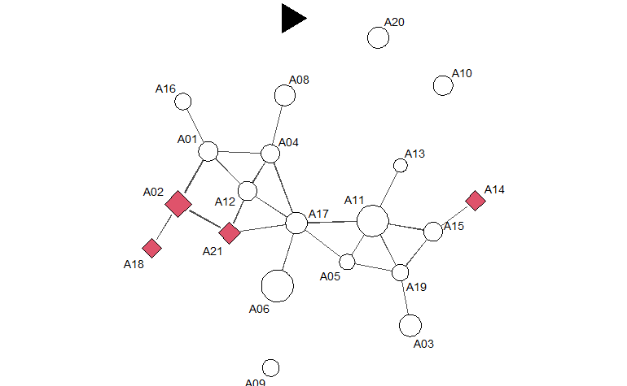

```r
par(mar=c(0,0,0,0))
gplot(Krackhardt_HighTech$Friendship_SymMin,
      gmode="graph",
      mode="fruchtermanreingold",
      jitter=F,
      edge.col="grey30",
      edge.lwd=.4,
      vertex.cex=Krackhardt_HighTech$Attributes$Tenure/20+1,
      vertex.col=1+(Krackhardt_HighTech$Attributes$Level==2)+(Krackhardt_HighTech$Attributes$Level==3)*-1,
      vertex.sides=3+(Krackhardt_HighTech$Attributes$Level==2)+(Krackhardt_HighTech$Attributes$Level==3)*50,
      displaylabels=TRUE,
      label.cex=.8)
```

## Using shape, color, and size on the collaboration network

- How to use shape, color and size of points to represent attributes on the larger scientific collaboration network (Figure 7.15)

Here we rely on the **colorRampPalette** function to create a gradation between two colors.

```r
Tenure<-(Borgatti_Scientists504$Attributes$Years)
TenureA<-(round(10*(Tenure)/max((Tenure))))
colfunc <- colorRampPalette(c("yellow", "red"))
COLWB<-colfunc(7)
TenureA2<-TenureA
TenureA2[TenureA==0]<-COLWB[1]
TenureA2[TenureA==1]<-COLWB[2]
TenureA2[TenureA==2]<-COLWB[3]
TenureA2[TenureA==3]<-COLWB[4]
TenureA2[TenureA==4]<-COLWB[5]
TenureA2[TenureA==5]<-COLWB[6]
TenureA2[TenureA==6]<-COLWB[6]
TenureA2[TenureA==7]<-COLWB[7]
TenureA2[TenureA==8]<-COLWB[7]
TenureA2[TenureA==9]<-COLWB[7]
TenureA2[TenureA==10]<-COLWB[7]
```

Using a dichotomization with values 4 or higher, using **gplot** we obtain:

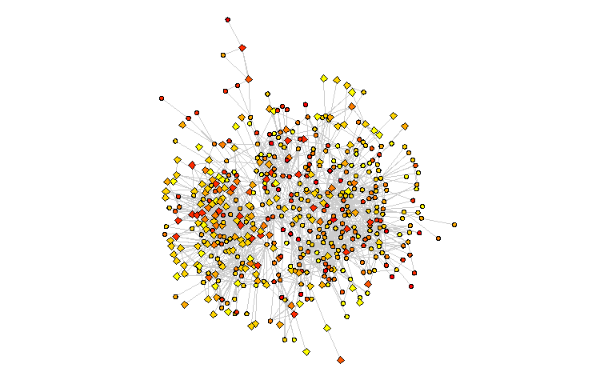

```r
par(mar=c(0,0,0,0))
gplot(Borgatti_Scientists504$Collaboration>3,
      mode="kamadakawai",
      gmode="graph",
      edge.col="grey80",
      edge.lwd=.2,
      vertex.col=TenureA2,
      vertex.cex=1+.7*(2-Borgatti_Scientists504$Attributes$Sex),
      vertex.sides=(Borgatti_Scientists504$Attributes$Sex-1)*47+4)
```

## Using labels on Padgett’s marriage network

- How to make changes to the labels based on attribute information when drawing the marriage network among Padgett’s Florentine families (Figure 7.16)

Relying on degree centrality, we can define the size of the labels with **label.cex**. To increase visibility we removed the node shapes.

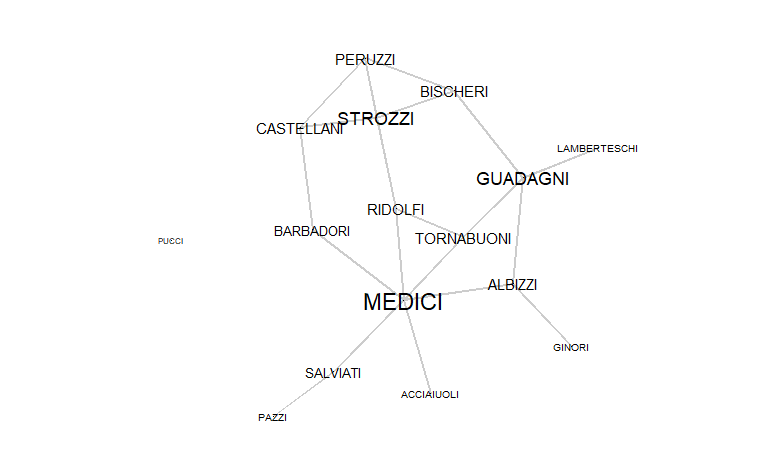

```r
par(mar=c(0,0,0,0))
PFM_Degree<-sna::degree(Padgett_FlorentineFamilies$Marriage)
gplot(Padgett_FlorentineFamilies$Marriage,
      gmode="graph",
      edge.col="grey80",
      edge.lwd=1.2,
      vertex.cex=0,
      vertex.col="white",
      displaylabels=TRUE,
      label.pos=5,
      label.cex=PFM_Degree/14+.45)
```